# Model validation

Virginia Morera-Pujol

14/02/2022

# 1 Model validation

To try and validate the results of the integrated species distribution models, we’re going to use the density data based on fecal sampling by Tim Burkitt, and the estimates of low, moderate and high density collected during Coillte’s desk surveys. We’ll extract the value of the prediction at the centroid of each sampled property and, using linear models, we’ll see how well the ISDM predictions can predict the observed values.

## 1.1 Load and modify dta

```r
# load data
projKM <- "+proj=tmerc +lat_0=53.5 +lon_0=-8 +k=0.99982 +x_0=600000 +y_0=750000 +ellps=GRS80 +units=km +no_defs"

ireland <- st_read("data/ireland_ITM.shp")
dens_data <- read.csv("data/density_latlon_coillte_dens_surveys.csv",
                      row.names = NULL)
coillte_data <- readRDS("data/PA_data_all.RDS")

RD_pred_resp <- readRDS("server_outputs/RD_pred_resp_def.RDS")
SD_pred_resp <- readRDS("server_outputs/SD_pred_resp_def.RDS")
FD_pred_resp <- readRDS("server_outputs/FD_pred_resp_def.RDS")

RD_pred_scaled <- rescale0to1(raster(RD_pred_resp["mean"]))
SD_pred_scaled <- rescale0to1(raster(SD_pred_resp["mean"]))
FD_pred_scaled <- rescale0to1(raster(FD_pred_resp["mean"]))

dens_sp <- dens_data %>%
  st_as_sf(coords = c("Longitude", "Latitude"), crs = st_crs(ireland)) %>%
  st_transform(projKM)

coillte_data <- coillte_data %>%
  dplyr::select(Red, Fallow, Sika, Year) %>%
  st_transform(projKM) %>%
  st_centroid()

ireland_proj <- st_transform(ireland, projKM)

preds <- stack(RD_pred_scaled,
               SD_pred_scaled,
               FD_pred_scaled)

names(preds) <- c("Red", "Sika", "Fallow")


culling_data <- read.csv("data/culling_data.csv", row.names = NULL)

culling_data <- culling_data %>%
  dplyr::select(Year = SeasonStart, County, Species, Deer_corrected, Deer_killed) %>%
  filter(Year >= 2010)
```

## 1.2 Validate models with Tim Burkitt data

Tim Burkitt’s data consists in a few properties sampled for several consecutive years. We can either calculate an average density for the properties sampled more than once, having only one dataset to validate against, or model each year’s data against the prediction. We’re going to do both here

### 1.2.1 Averaged densities

First we average densities in properties sampled more than once

```r
dens_avg <- dens_sp %>%
  group_by(Site_id, Species) %>%
  summarise(Dens.avg = mean(Deer.Density, na.rm = T)) %>%
  ungroup()
```

We now extract the values from the raster

```r
pred_values <- raster::extract(preds, dens_avg)

dens_avg <- dens_avg %>%
  mutate(Red_pred = pred_values[,1],
         Sika_pred = pred_values[,2],
         Fallow_pred = pred_values[,3])
```

And finally we generate the plots

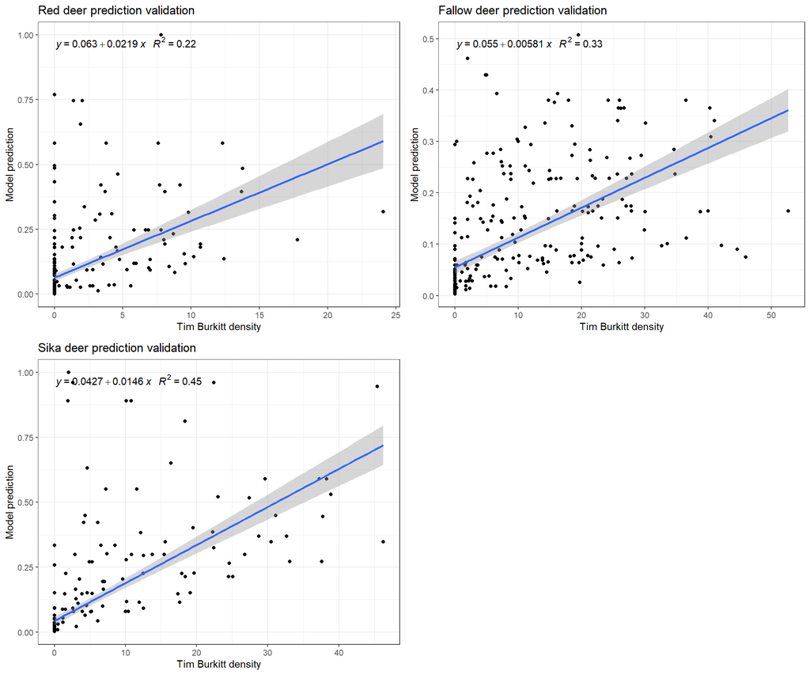

```r
my.formula <- y ~ x

RD_plot <- dens_avg %>%
    # filter(prediction > 0.1) %>%
    # filter(Deer.Density > 0) %>%
    filter(Species == "RedDeer") %>%
    ggplot(aes(x = Dens.avg, y = Red_pred)) +
    geom_point() +
    geom_smooth(method='lm', formula= my.formula) +
    stat_poly_eq(formula = my.formula,
                 aes(label = paste(..eq.label.., ..rr.label.., sep = "~~~")),
                 parse = TRUE) +
    theme_bw() +
    labs(x = "Tim Burkitt density", y = "Model prediction",
         title = "Red deer prediction validation")

FD_plot <- dens_avg %>%
    # filter(prediction > 0.1) %>%
    # filter(Deer.Density > 0) %>%
    filter(Species == "FallowDeer") %>%
    ggplot(aes(x = Dens.avg, y = Fallow_pred)) +
    geom_point() +
    geom_smooth(method='lm', formula= my.formula) +
    stat_poly_eq(formula = my.formula,
                 aes(label = paste(..eq.label.., ..rr.label.., sep = "~~~")),
                 parse = TRUE) +
    theme_bw() +
    labs(x = "Tim Burkitt density", y = "Model prediction",
         title = "Fallow deer prediction validation")

SD_plot <- dens_avg %>%
    # filter(prediction > 0.1) %>%
    # filter(Deer.Density > 0) %>%
    filter(Species == "SikaDeer") %>%
    ggplot(aes(x = Dens.avg, y = Sika_pred)) +
    geom_point() +
    geom_smooth(method='lm', formula= my.formula) +
    stat_poly_eq(formula = my.formula,
                 aes(label = paste(..eq.label.., ..rr.label.., sep = "~~~")),
                 parse = TRUE) +
    theme_bw() +
    labs(x = "Tim Burkitt density", y = "Model prediction",
         title = "Sika deer prediction validation")

cowplot::plot_grid(RD_plot, FD_plot, SD_plot)
```

### 1.2.2 Densities by year

Extract raster values for the full dataset

```r
pred_yearly_values <- raster::extract(preds, dens_sp)

dens_sp <- dens_sp %>%
  mutate(Red_pred = pred_yearly_values[,1],
         Sika_pred = pred_yearly_values[,2],
         Fallow_pred = pred_yearly_values[,3])
```

#### 1.2.2.1 Red deer

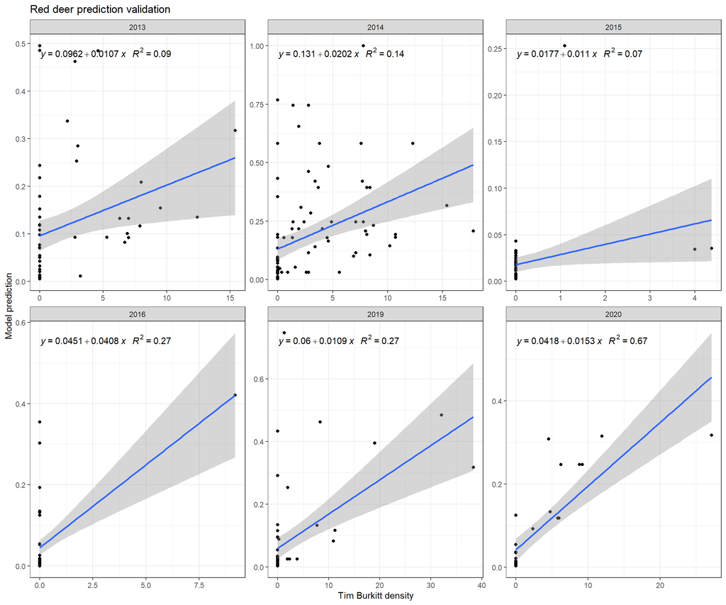

```r
(RD_plot <- dens_sp %>%
   # filter(prediction > 0.1) %>%
   # filter(Dens.avg > 0) %>%
   filter(Species == "RedDeer") %>%
   group_by(Year) %>%
   mutate(count = n()) %>%
   ungroup() %>%
   filter(count > 15) %>%  # avoid plotting years with less than 10 properties sampled
   ggplot(aes(x = Deer.Density, y = Red_pred)) +
   geom_point() +
   geom_smooth(method='lm', formula= my.formula) +
   stat_poly_eq(formula = my.formula,
                aes(label = paste(..eq.label.., ..rr.label.., sep = "~~~")),
                parse = TRUE) +
   theme_bw() +
   facet_wrap(~Year, scales = "free") +
   labs(x = "Tim Burkitt density", y = "Model prediction",
        title = "Red deer prediction validation"))
```

#### 1.2.2.2 Fallow deer

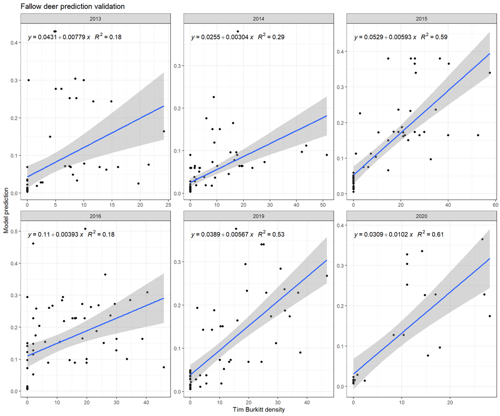

```r
(FD_plot <- dens_sp %>%
   # filter(prediction > 0.1) %>%
   # filter(Dens.avg > 0) %>%
   filter(Species == "FallowDeer") %>%
   group_by(Year) %>%
   mutate(count = n()) %>%
   ungroup() %>%
   filter(count > 15) %>%  # avoid plotting years with less than 10 properties sampled
   ggplot(aes(x = Deer.Density, y = Fallow_pred)) +
   geom_point() +
   geom_smooth(method='lm', formula= my.formula) +
   stat_poly_eq(formula = my.formula,
                aes(label = paste(..eq.label.., ..rr.label.., sep = "~~~")),
                parse = TRUE) +
   theme_bw() +
   facet_wrap(~Year, scales = "free") +
   labs(x = "Tim Burkitt density", y = "Model prediction",
        title = "Fallow deer prediction validation"))
```

#### 1.2.2.3 Sika deer

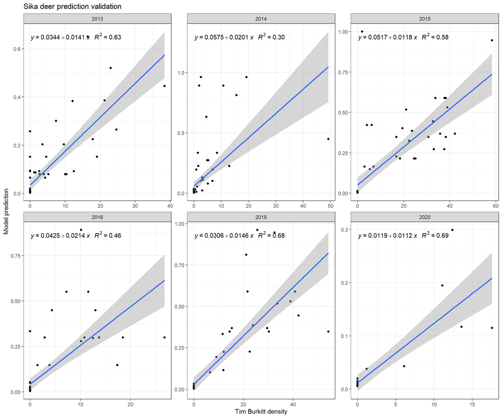

```r
(FD_plot <- dens_sp %>%
   # filter(prediction > 0.1) %>%
   # filter(Dens.avg > 0) %>%
   filter(Species == "SikaDeer") %>%
   group_by(Year) %>%
   mutate(count = n()) %>%
   ungroup() %>%
   filter(count > 15) %>%  # avoid plotting years with less than 10 properties sampled
   ggplot(aes(x = Deer.Density, y = Sika_pred)) +
   geom_point() +
   geom_smooth(method='lm', formula= my.formula) +
   stat_poly_eq(formula = my.formula,
                aes(label = paste(..eq.label.., ..rr.label.., sep = "~~~")),
                parse = TRUE) +
   theme_bw() +
   facet_wrap(~Year, scales = "free") +
   labs(x = "Tim Burkitt density", y = "Model prediction",
        title = "Sika deer prediction validation"))
```

## 1.3 Validate models with Coillte survey estimates

First we extract the prediction value at the properties centroids

```r
est_pred <- raster::extract(preds, coillte_data)

names(est_pred) <- c("Red", "Sika", "Fallow")

coillte_data <- coillte_data %>%
  mutate(Red_pred = est_pred[,1],
         Sika_pred = est_pred[,2],
         Fallow_pred = est_pred[,3])
```

Now plot the validations

### 1.3.1 Red deer

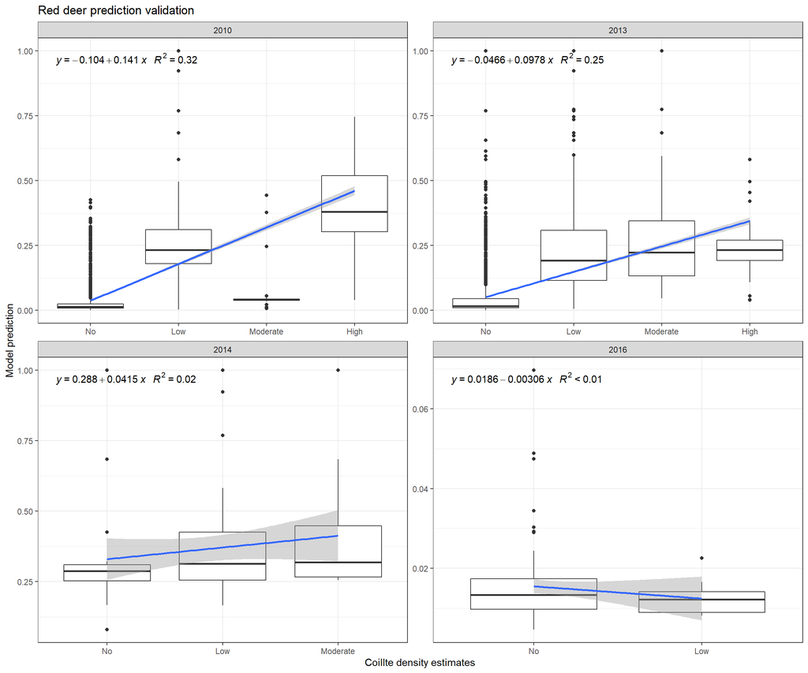

```r
my.formula <- y ~ x

(RD_plot <- coillte_data %>%
    mutate(Red = factor(Red, levels = c("No", "Low", "Moderate", "High")),
           Red.num = as.numeric(Red)) %>%
    ggplot(aes(x = Red.num, y = Red_pred)) +
    geom_boxplot(aes(x = Red, y = Red_pred)) +
    # geom_point() +
    geom_smooth(method='lm', formula= my.formula) +
    stat_poly_eq(formula = my.formula,
                 aes(label = paste(..eq.label.., ..rr.label.., sep = "~~~")),
                 parse = TRUE) +
    theme_bw() +
    facet_wrap(~Year, scales = "free") +
    labs(x = "Coillte density estimates", y = "Model prediction", title = "Red deer prediction validation"))
```

### 1.3.2 Fallow deer

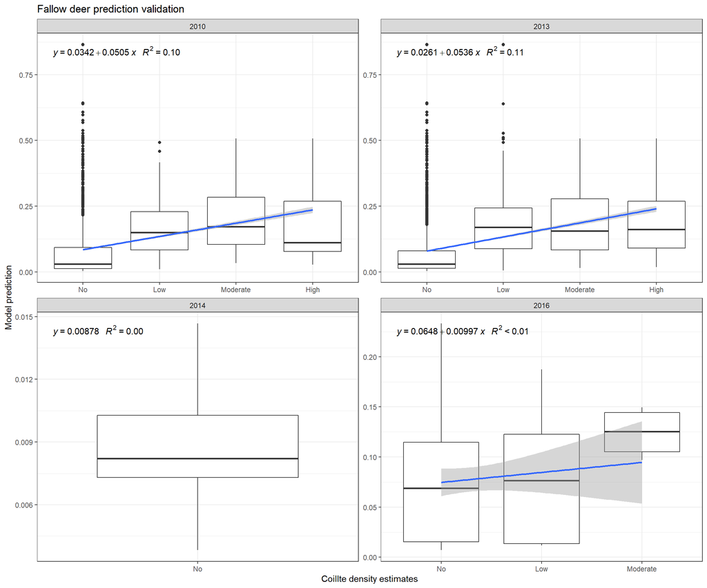

```r
my.formula <- y ~ x

(FD_plot <- coillte_data %>%
    mutate(Fallow = factor(Fallow, levels = c("No", "Low", "Moderate", "High")),
           Fallow.num = as.numeric(Fallow)) %>%
    ggplot(aes(x = Fallow.num, y = Fallow_pred)) +
    geom_boxplot(aes(x = Fallow, y = Fallow_pred)) +
    # geom_point() +
    geom_smooth(method='lm', formula= my.formula) +
    stat_poly_eq(formula = my.formula,
                 aes(label = paste(..eq.label.., ..rr.label.., sep = "~~~")),
                 parse = TRUE) +
    theme_bw() +
    facet_wrap(~Year, scales = "free") +
    labs(x = "Coillte density estimates", y = "Model prediction", title = "Fallow deer prediction validation"))
```

### 1.3.3 Sika deer

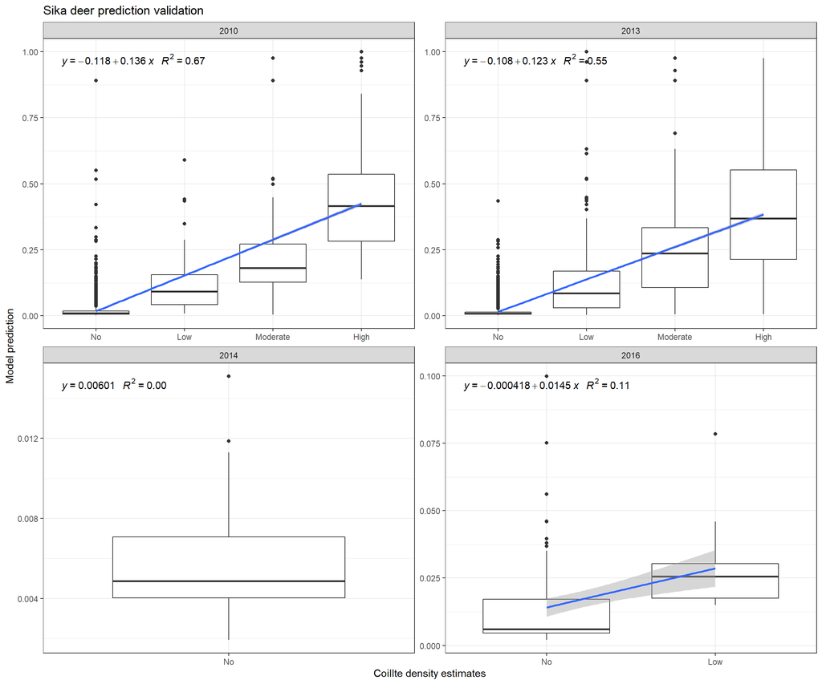

```r
my.formula <- y ~ x

(SD_plot <- coillte_data %>%
    mutate(Sika = factor(Sika, levels = c("No", "Low", "Moderate", "High")),
           Sika.num = as.numeric(Sika)) %>%
    ggplot(aes(x = Sika.num, y = Sika_pred)) +
    geom_boxplot(aes(x = Sika, y = Sika_pred)) +
    # geom_point() +
    geom_smooth(method='lm', formula= my.formula) +
    stat_poly_eq(formula = my.formula,
                 aes(label = paste(..eq.label.., ..rr.label.., sep = "~~~")),
                 parse = TRUE) +
    theme_bw() +
    facet_wrap(~Year, scales = "free") +
    labs(x = "Coillte density estimates", y = "Model prediction", title = "Sika deer prediction validation"))
```

## 1.4 Validate models by county with culling returns

We first have to add up the predicted intensity by county

```r
bycounty_abundances <- data.frame(
  County = ireland$NAME_TAG,
  Red_model = NA,
  Sika_model = NA,
  Fallow_model = NA
)

for (i in seq_along(bycounty_abundances$County)) {
  # i = 1
  county <- ireland_proj %>% filter(NAME_TAG == bycounty_abundances$County[i])
  cropped <- mask(crop(preds, county), county)
  # print(levelplot(cropped, main = bycounty_abundances$County[i]) +
  #         latticeExtra::layer(sp.polygons(as_Spatial(county))))

  sum_raster_cells <-cellStats(cropped, 'sum')
  bycounty_abundances[i, 2:4] <- sum_raster_cells
}

bycounty_abundances %>%
  kableExtra::kable(digits = 2, align = "rrrr", caption = "Added abundances by county") %>%
  kableExtra::kable_classic(full_width = F, html_font = "Cambria")
```

Added abundances by county

| County | Red_model | Sika_model | Fallow_model |
| --- | --- | --- | --- |
| Donegal | 40.71 | 1.17 | 1.48 |
| Mayo | 31.75 | 3.89 | 9.37 |
| Roscommon | 3.70 | 0.49 | 27.50 |
| Kerry | 17.80 | 29.04 | 1.49 |
| Limerick | 1.54 | 1.01 | 2.60 |
| Clare | 2.35 | 1.23 | 6.59 |
| Waterford | 0.92 | 0.48 | 9.33 |
| Kilkenny | 0.68 | 0.95 | 2.36 |
| Meath | 2.88 | 0.48 | 2.82 |
| Antrim | 4.91 | 0.83 | 7.48 |
| Monaghan | 0.59 | 0.73 | 4.42 |
| Louth | 1.38 | 0.21 | 0.85 |
| Sligo | 9.97 | 0.50 | 6.19 |
| Laois | 0.38 | 0.49 | 6.10 |
| Cork | 4.76 | 8.42 | 7.87 |
| Westmeath | 0.64 | 0.21 | 5.49 |
| Longford | 0.30 | 0.12 | 2.74 |
| Galway | 21.97 | 1.21 | 21.91 |
| Offaly | 0.75 | 0.39 | 9.81 |
| Leitrim | 2.49 | 0.60 | 5.33 |
| Tyrone | 5.29 | 3.79 | 6.82 |
| Dublin | 1.25 | 5.23 | 1.32 |
| Armagh | 1.72 | 0.39 | 3.14 |
| Londonderry | 4.45 | 0.66 | 2.16 |
| Down | 4.93 | 0.90 | 9.16 |
| Tipperary | 1.14 | 1.03 | 17.17 |
| Cavan | 0.83 | 0.58 | 9.65 |
| Wexford | 1.12 | 4.33 | 1.04 |
| Carlow | 0.37 | 2.72 | 0.46 |
| Kildare | 1.46 | 3.40 | 2.07 |
| Wicklow | 1.35 | 24.16 | 1.91 |
| Fermanagh | 5.19 | 3.18 | 8.31 |

### 1.4.1 Validate with average cullings

We now merge that dataset with the culling returns (averaging the last 10 years) (Remember that there is no culling data for the NI counties in this dataset)

```r
cull_validating_avg <- culling_data %>%
  group_by(County, Species) %>%
  summarise(Deer_corrected = mean(Deer_corrected, na.rm = T)) %>%
  ungroup() %>%
  full_join(bycounty_abundances)
```

And finally plot

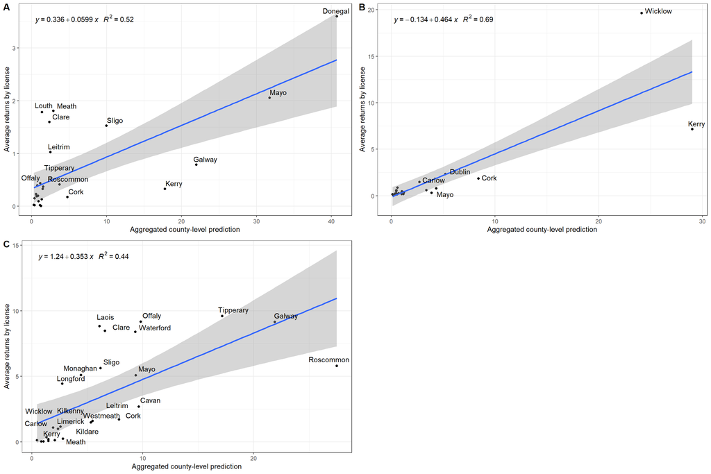

```r
my.formula <-  y~x

RD_cull <- cull_validating_avg %>%
  filter(Species == "Red") %>%
  ggplot(aes(y = Deer_corrected, x = Red_model)) +
  geom_point() +
  geom_smooth(method='lm', formula= my.formula) +
  stat_poly_eq(formula = my.formula,
               aes(label = paste(..eq.label.., ..rr.label.., sep = "~~~")),
               parse = TRUE) +
  geom_text_repel(aes(label = County), nudge_x = 1, nudge_y = 0.1, min.segment.length = 10) +
  theme_bw() +
  labs(y = "Average returns by license",
       x = "Aggregated county-level prediction")


FD_cull <- cull_validating_avg %>%
  filter(Species == "Fallow") %>%
  ggplot(aes(y = Deer_corrected, x = Fallow_model)) +
  geom_point() +
  geom_smooth(method='lm', formula= my.formula) +
  stat_poly_eq(formula = my.formula,
               aes(label = paste(..eq.label.., ..rr.label.., sep = "~~~")),
               parse = TRUE) +
  geom_text_repel(aes(label = County), nudge_x = 1, nudge_y = 0.5, min.segment.length = 10) +
  theme_bw() +
  labs(y = "Average returns by license",
       x = "Aggregated county-level prediction")

SD_cull <- cull_validating_avg %>%
  filter(Species == "Sika") %>%
  ggplot(aes(y = Deer_corrected, x = Sika_model)) +
  geom_point() +
  geom_smooth(method='lm', formula= my.formula) +
  stat_poly_eq(formula = my.formula,
               aes(label = paste(..eq.label.., ..rr.label.., sep = "~~~")),
               parse = TRUE) +
  geom_text_repel(aes(label = County), nudge_x = 1, nudge_y = 0.1, min.segment.length = 10) +
  theme_bw() +
  labs(y = "Average returns by license",
       x = "Aggregated county-level prediction")

# Cairo::CairoPDF(file = "Fig4.pdf", width = 15, height = 12)
cowplot::plot_grid(RD_cull, SD_cull, FD_cull, ncol = 2, labels = c("A", "B", "C"))
```

```r
# dev.off()
```

### 1.4.2 Validate with total cullings

We now merge that dataset with the culling returns (averaging the last 10 years) (Remember that there is no culling data for the NI counties in this dataset)

```r
cull_validating_avg <- culling_data %>%
  group_by(County, Species) %>%
  summarise(Deer_total = mean(Deer_killed, na.rm = T)) %>%
  ungroup() %>%
  full_join(bycounty_abundances)
```

And finally plot

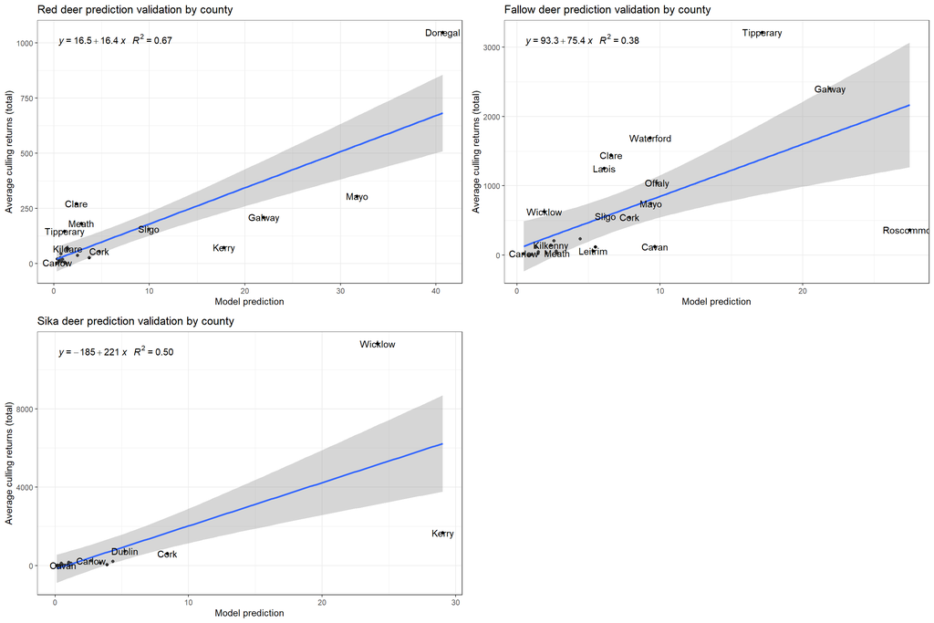

```r
my.formula <-  y~x

RD_cull <- cull_validating_avg %>%
  filter(Species == "Red") %>%
  ggplot(aes(y = Deer_total, x = Red_model)) +
  geom_point() +
  geom_smooth(method='lm', formula= my.formula) +
  stat_poly_eq(formula = my.formula,
               aes(label = paste(..eq.label.., ..rr.label.., sep = "~~~")),
               parse = TRUE) +
  geom_text(aes(label = County), check_overlap = TRUE, nudge_y = 1.5) +
  theme_bw() +
  labs(y = "Average culling returns (total)", x = "Model prediction",
       title = "Red deer prediction validation by county")


FD_cull <- cull_validating_avg %>%
  filter(Species == "Fallow") %>%
  ggplot(aes(y = Deer_total, x = Fallow_model)) +
  geom_point() +
  geom_smooth(method='lm', formula= my.formula) +
  stat_poly_eq(formula = my.formula,
               aes(label = paste(..eq.label.., ..rr.label.., sep = "~~~")),
               parse = TRUE) +
  geom_text(aes(label = County), check_overlap = TRUE, nudge_y = 1.5) +
  theme_bw() +
  labs(y = "Average culling returns (total)", x = "Model prediction",
       title = "Fallow deer prediction validation by county")

SD_cull <- cull_validating_avg %>%
  filter(Species == "Sika") %>%
  ggplot(aes(y = Deer_total, x = Sika_model)) +
  geom_point() +
  geom_smooth(method='lm', formula= my.formula) +
  stat_poly_eq(formula = my.formula,
               aes(label = paste(..eq.label.., ..rr.label.., sep = "~~~")),
               parse = TRUE) +
  geom_text(aes(label = County), check_overlap = TRUE, nudge_y = 1.5) +
  theme_bw() +
  labs(y = "Average culling returns (total)", x = "Model prediction",
       title = "Sika deer prediction validation by county")


cowplot::plot_grid(RD_cull, FD_cull, SD_cull, ncol = 2)
```